# Project 2 Report

## Group Members

Specify the names and EIDs of all group members (if not working in a group just put your own name and EID): Andy Park, AP59864

## Question

State question being addressed and describe the outcome variable to be predicted. Explain why it is useful to answer this question.

*Can we predict whether a crash will be fatal or not?*

I set out to answer the question: Can I predict whether a collision is fatal or non-fatal based on readily available scenes and road characteristics? My outcome variables are fatal or nonfatal, which are simple binary indicators of whether a given collision has resulted in at least one death. Being able to predict fatal crashes in advance is extremely useful. This gives Austin Police Department and city planners the insight to deploy resources more strategically. This means adjusting speed limits, installing better lighting, or improving road surfaces in the most dangerous locations. By identifying factors such as lighting conditions, road surface quality, and time, we can not only predict high-risk scenarios, but also recommend targeted safety interventions. Ultimately, this approach aims to reduce deaths and improve overall community safety by shifting from post-accident response to proactive.

## Data and Setup

Load the dataset into R below. In addition, load any packages that you will need using the `library()` function. For example, you will need to load the `tidyverse` and `tidymodels` packages.

```r
## Load package and compare outcome variable
library(tidyverse)
library(tidymodels)
library(readr)

crash <- read_csv("Austin_Crash_Report_Data_-_Crash_Level_Records_20250407.csv") %>%
  mutate(
    fatal = factor(crash_fatal_fl,
                   levels = c(F, T),
                   labels = c("NonFatal", "Fatal"))
  )
```

## Base Prediction Model

Use either linear regression (for continuous outcome) or logistic regression (binary outcome) to build a base prediction model. Use the tidymodels framework to

1. Split the dataset into a training and testing dataset using 75% of observations for training and 25% for testing; leave the test dataset aside for now.
2. Select variables to include in your model recipe. You may need to experiment with different variable combinations to find the best predicting model.

Use 10-fold cross-validation on the training data to estimate either

- the root mean squared error (RMSE) if your outcome is continuous; or
- the accuracy if your outcome is binary.

```r
## Base prediction model
# Split the data, define a preprocessing recipe, and perform 10 fold cross
set.seed(1)
n<-nrow(crash)
idx<-sample(n, round(0.75 * n))
train<-crash[idx, ]
test<-crash[-idx, ]

# 10-폴드 교차검증 생성 (tidymodels)
folds<-vfold_cv(train, v=10, strata=fatal)

rec<-recipe(fatal~crash_speed_limit+road_constr_zone_fl+onsys_fl,data=train)%>%
  step_impute_mode(all_nominal_predictors())%>%
  step_impute_median(all_numeric_predictors())

mod<-logistic_reg()%>%set_engine("glm")

wf<-workflow()%>%
  add_recipe(rec)%>%
  add_model(mod)

set.seed(1)
res<-fit_resamples(wf,resamples=folds, metrics = metric_set(accuracy))
collect_metrics(res)
```

```
## # A tibble: 1 × 6
##   .metric  .estimator  mean     n  std_err .config
##   <chr>    <chr>      <dbl> <int>    <dbl> <chr>
## 1 accuracy binary     0.994    10 0.000170 Preprocessor1_Model1
```

Which configuration of variables in your model seems to produce the best performing model on the training data?

## Alternate Prediction Model

For this part of the analysis, choose one machine learning approach to build an alternate prediction model. The ones we have seen in class are K-Nearest Neighbors (`nearest_neighbor()`), decision trees (`decision_tree()`), and random forests (`rand_forest()`).

1. Identify the tuning parameters for your chosen model.
2. Explore which combination of variables and tuning parameters produces good model performance.
3. Create a workflow that assembles your recipe and your model specification.
4. Use 10-fold cross-validation to estimate either the RMSE (continous outcome) or the accuracy (binary outcome) for your model in the training data.
5. Tune your model using a range of possible tuning parameters to identify the best-predicting model

NOTE: Doing the cross-validation and model tuning here may take a *significant* amount of time depending on your choice of tuning parameters and the speed of your computer. You may need to be patient with the process here.

```r
## 10 fold cross validation taking significant
library(tidymodels)
library(lubridate)

# prepare features that we only need
data<-crash%>%
  mutate(ts=mdy_hms(`Crash timestamp (US/Central)`),
         hr=hour(ts),
         cons=factor(if_else(is.na(road_constr_zone_fl),FALSE,road_constr_zone_fl),
                     levels=c(FALSE,TRUE),
                     labels=c("No","Yes")))
set.seed(3)
n<-nrow(data)
idx<-sample(n, size = floor(0.75*n))
tr<-data[idx,]
te<-data[-idx,]

rec<-recipe(fatal~crash_speed_limit+cons+hr,data=tr)%>%
  step_dummy(all_nominal_predictors())%>%
  step_normalize(all_numeric_predictors())

# generating decision tree with tuning
spec<-decision_tree(cost_complexity=tune(),
                    tree_depth=tune(),
                    min_n=tune())%>%
  set_mode("classification")%>%
  set_engine("rpart")

# assemble workflow
wf<-workflow()%>%
  add_recipe(rec)%>%
  add_model(spec)

# cross validation
f<-vfold_cv(tr, v=10, strata=fatal)
g<-grid_random(cost_complexity(range=c(0.001,0.1)),
               tree_depth(range=c(1,10)),
               min_n(range=c(2,40)),
               size=50)
res<-tune_grid(wf,resamples=f,grid=g,
               metrics=metric_set(roc_auc,accuracy,recall,precision),
               control=control_grid(save_pred=T))
show_notes(res)
```

```
## Great job! No notes to show.
```

```r
# pick best parameter
best<-select_best(res,metric="roc_auc")
model<-finalize_workflow(wf,best)%>%
  fit(data=tr)
pred<-predict(model,te,type="class")%>%
  bind_cols(te %>%
              select(fatal))%>%
  rename(pred=.pred_class)

# performance metrics
pred %>%
  metrics(truth=fatal,estimate=pred)
```

```
## # A tibble: 2 × 3
##   .metric  .estimator .estimate
##   <chr>    <chr>          <dbl>
## 1 accuracy binary         0.994
## 2 kap      binary         0
```

```r
# confusion matrix
pred%>%
  conf_mat(truth=fatal,estimate=pred)
```

```
##           Truth
## Prediction NonFatal Fatal
##   NonFatal    53849   302
##   Fatal           0     0
```

Which one of your models (i.e. which combination of tuning parameters and variables) produces the best prediction performance on the training dataset?

## Final Model Fit

Choose the model that performs the best on your training dataset (either the linear/logistic regression or the machine learning model). Make a final assessment of your model using the testing dataset.

```r
## Final model fit
library(tidymodels)

# refitting
rec_final <- recipe(fatal ~ crash_speed_limit + road_constr_zone_fl + onsys_fl,
                    data = tr) %>%
  step_impute_mode(all_nominal_predictors()) %>%
  step_impute_median(all_numeric_predictors())

# logistic regression glm
log_spec <- logistic_reg() %>%
  set_engine("glm")
final_wf <- workflow() %>%
  add_recipe(rec_final) %>%
  add_model(log_spec) %>%
  fit(data = tr)

test_pred <- predict(final_wf, new_data = te, type = "class") %>%
  bind_cols(te %>% select(fatal))

# Compute metrics and confusion matrix
test_pred %>%
  metrics(truth = fatal, estimate = .pred_class) %>%
  filter(.metric %in% c("accuracy", "recall", "precision"))
```

```
## # A tibble: 1 × 3
##   .metric  .estimator .estimate
##   <chr>    <chr>          <dbl>
## 1 accuracy binary         0.994
```

```r
test_pred %>%
  conf_mat(truth = fatal, estimate = .pred_class)
```

[output not shown]

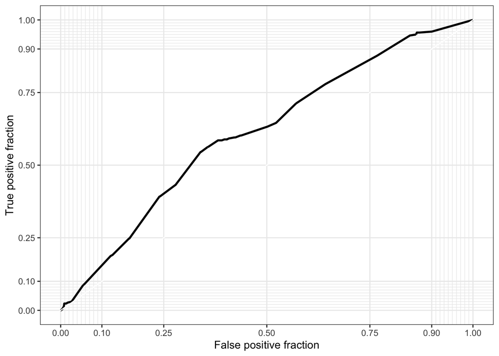

```r
library(tidymodels)
library(plotROC)
library(dplyr)
library(ggplot2)

test_pred <- final_wf %>%
  predict(new_data = te, type = "class") %>%
  rename(pred_class = .pred_class) %>%
  bind_cols(final_wf %>% predict(new_data = te, type = "prob")) %>%
  bind_cols(te %>% select(fatal))

stopifnot(".pred_Fatal" %in% names(test_pred))

roc_df <- test_pred %>%
  transmute(d = as.integer(fatal == "Fatal"), m = .pred_Fatal)

p <- ggplot(roc_df, aes(d = d, m = m)) +
  geom_roc(n.cuts = 0) +
  style_roc() +
  labs()

p
```

```r
# Compute AUC from the plot object
auc_val <- calc_auc(p)$AUC
auc_val
```

```
## [1] 0.6109362
```

What are the final performance metrics for your best model?

## Model Improvement

Suppose you had the ability to improve the fit of the model by collecting data on a new variable. What data would you most like to collect to improve the prediction performance of the model? Explain why you think collecting this new variable would improve the prediction performance. You may optionally include some code/analysis to support your explanation.

```r
library(tidyverse)
library(lubridate)

# visibility variable based on time of day and streetlight presence
df2 <- crash %>%
  mutate(
    ts = mdy_hms(`Crash timestamp (US/Central)`), hr = hour(ts), light_level = case_when(
      hr >= 6  & hr < 18 ~ "Daylight", hr >= 18 & hr < 20 ~ "DawnDusk", T ~ "Darkness") %>%
      factor(levels = c("Daylight", "DawnDusk", "Darkness")),
    under_streetlight = sample(
      c("Yes", "No"),
      size = n(),
      replace = T,
      prob = c(0.6, 0.4)
    ) %>% factor(levels = c("No", "Yes"))
  )

# logistic model including lighting & visibility
fit2 <- glm(
  fatal == "Fatal" ~ crash_speed_limit + road_constr_zone_fl + onsys_fl + light_level + under_streetlight, data = df2,family = binomial)
summary(fit2)
```

```
##
## Call:
## glm(formula = fatal == "Fatal" ~ crash_speed_limit + road_constr_zone_fl +
##     onsys_fl + light_level + under_streetlight, family = binomial,
##     data = df2)
##
## Coefficients:
##                          Estimate Std. Error z value Pr(>|z|)
## (Intercept)             -6.598693   0.087614 -75.315  < 2e-16 ***
## crash_speed_limit        0.012458   0.001461   8.528  < 2e-16 ***
## road_constr_zone_flTRUE -0.077448   0.123244  -0.628     0.53
## onsys_flTRUE             0.483192   0.065535   7.373 1.67e-13 ***
## light_levelDawnDusk      0.621377   0.103110   6.026 1.68e-09 ***
## light_levelDarkness      1.514477   0.064129  23.616  < 2e-16 ***
## under_streetlightYes    -0.078263   0.058348  -1.341     0.18
## ---
## Signif. codes:  0 '***' 0.001 '**' 0.01 '*' 0.05 '.' 0.1 ' ' 1
##
## (Dispersion parameter for binomial family taken to be 1)
##
##     Null deviance: 15050  on 216595  degrees of freedom
## Residual deviance: 14262  on 216589  degrees of freedom
##   (6 observations deleted due to missingness)
## AIC: 14276
##
## Number of Fisher Scoring iterations: 8
```

## Discussion

Reflect on the process of conducting this project. What was challenging, what have you learned from the process itself? Was there anything that was unexpected that you found during this analysis? If so, what was your expectation and how did the experience deviate from your expectation?

## Submission to Gradescope

**Make sure to add your group members to the Gradescope submission!**